# Disparities in the impacts of co-management on fishers’ livelihoods

Ruano-Chamorro et al.

2022-11-28

```r
INEQ = read.csv("INEQ_22.csv",
                header = TRUE,
                dec = ".")
```

### LOAD PACKAGES

```r
library(ggplot2)
library(gridExtra)
library(lattice)
library(lme4)
library(arm)
library(scales)
library(DHARMa)
library(insight)
#library(parameters)
library(performance)
#library(sjPlot)
library(tidyverse)
library(graphics)
library(vcd)
#library(ggstatsplot)
library(dplyr)
library(ggpubr)
library(MuMIn)
library(car)
```

### PREPARE DATA FOR ANALYSIS

Meaning of variables:

- site = community
- OrgEffLivelihood = Impact on individual livelihoods. 5 point Likert scale
- OrgEffComm = Impact on community. 5 point Likert scale
- yrseducation = years of education
- migrant = being a migrant or not
- marlivprim = fishing is a primary livelihood
- occdiv = occupational diversity
- mslall = wealth, material life style
- trustleaders = trust in leaders
- decispart = level of participation in decision-making processes
- CommEvent = participation in community events
- popn = population size
- distmktreg = distance to markets
- regr = presence or absence of gear restrictions
- regg = presence or absence of acess restrictions
- rega = presence or absence of area restriction
- clearboundaries = presence or absence of clear boundaries
- confmechinter = conflict resolution mechanisms
- GradSanctions = presence or absence of graduated sanctions

Eliminate don’t knows and NAs from OrgEffLivelihood and OrgEffComm.

```r
str(INEQ$OrgEffLivelihood)
```

```
##  int [1:1191] 3 4 3 4 3 5 2 4 1 4 ...
```

```r
INEQ$OrgEffLivelihood_cat<-as.factor(INEQ$OrgEffLivelihood)
str(INEQ$OrgEffComm)
```

```
##  int [1:1191] 1 5 1 3 5 4 1 4 2 4 ...
```

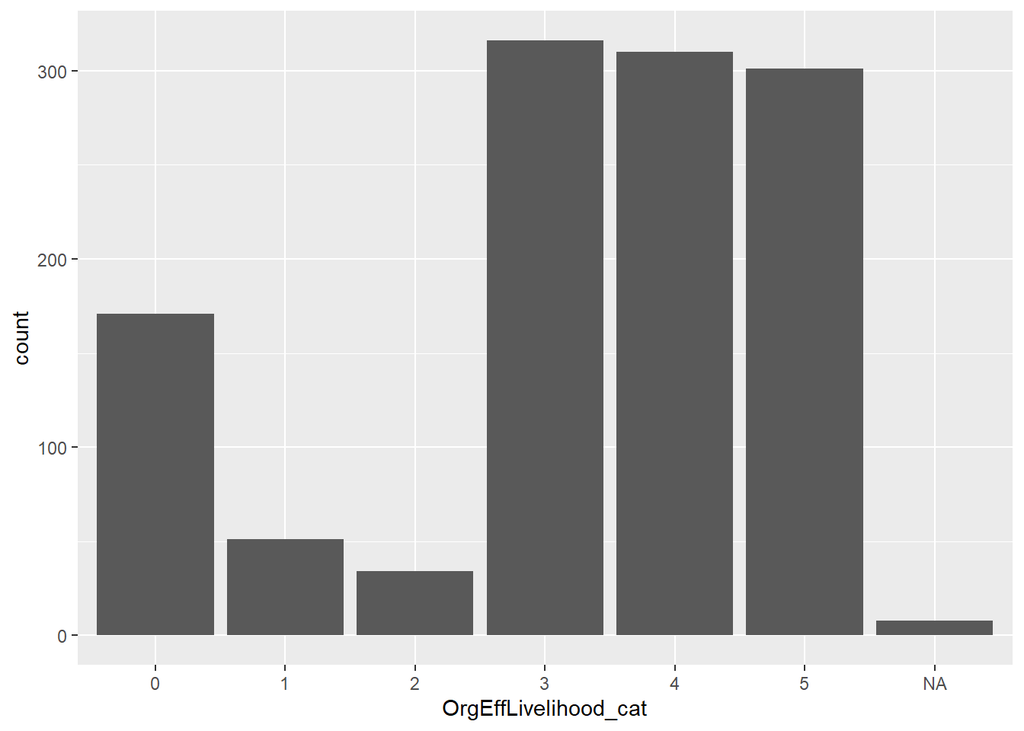

```r
INEQ$OrgEffComm_cat<-as.factor(INEQ$OrgEffComm)

ggplot(INEQ,aes(OrgEffLivelihood_cat))+geom_bar()#there are more than 150 don't knows
```

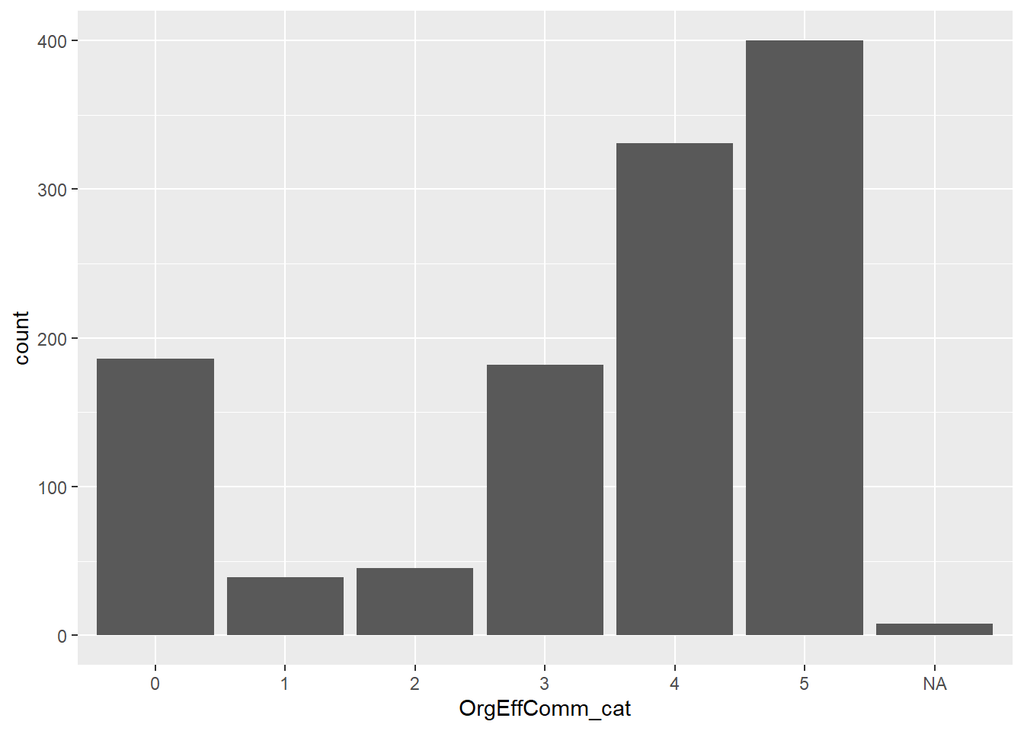

```r
ggplot(INEQ,aes(OrgEffComm_cat))+geom_bar()#there are less than 200 don't knows
```

```r
#eliminate don't knows
INEQ <- INEQ[INEQ$OrgEffLivelihood!=0,]
INEQ <- INEQ[INEQ$OrgEffComm!=0,]

#eliminate NAs

which(is.na(INEQ$OrgEffLivelihood))
```

```
## [1] 847 858 882 895 904 906 927 960
```

```r
INEQ<-INEQ[-c(847, 858, 882, 895, 904, 906, 927, 960),]

which(is.na(INEQ$OrgEffComm))
```

```
## integer(0)
```

```r
colSums(is.na(INEQ))
```

```
##                 dbid             sampleid             datatype
##                    0                    0                    0
##              country                 site     OrgEffLivelihood
##                    0                    0                    0
##           OrgEffComm                  sex         yrseducation
##                    0                    0                    1
##              migrant           marlivprim               occdiv
##                    1                    0                    0
##               mslall         trustleaders            decispart
##                    0                    1                    2
##            CommEvent                 popn           distmktreg
##                   35                    0                    0
##                 regr                 regg                 rega
##                    0                    0                    0
##      clearboundaries        confmechinter        GradSanctions
##                    0                    0                    0
## OrgEffLivelihood_cat       OrgEffComm_cat
##                    0                    0
```

```r
dim(INEQ)#968
```

```
## [1] 968  26
```

### CALCULATE DISPARITY

In this script disparity = inequality

### Calculate Disparity 1 (Objective)

Disparity 1 (Objective disparity) = (how the individual think he/she benefits from co-management) - (average of how individuals think they benefit from co-management)

```r
# Inequality1 (or Disparity 1) = OrgEffLivelihood - average at
#community level of all OrgEffLivelihood
avgeffliv.table <- setNames(aggregate(as.numeric(INEQ$OrgEffLivelihood)~INEQ$site,FUN=mean),
     c("site","avgeffliv"))#table with averages of how individual think they benefit
#per site ("objective measure" of how the community benefits)
INEQ.outcomes <- merge(INEQ,avgeffliv.table, by = intersect("site", "site"),
                       all=FALSE) #average has been added to the data frame INEQ
INEQ.outcomes$Inequality1_rec = as.numeric(INEQ.outcomes$OrgEffLivelihood) -
  as.numeric(INEQ.outcomes$avgeffliv)
```

### Calculate Disparity 2 (Subjective, perceived)

Disparity 2 (Subjective disparity, or perceived disparity) = (how the individual think he/she benefits from co-management) - (how the individual thinks the community benefits)

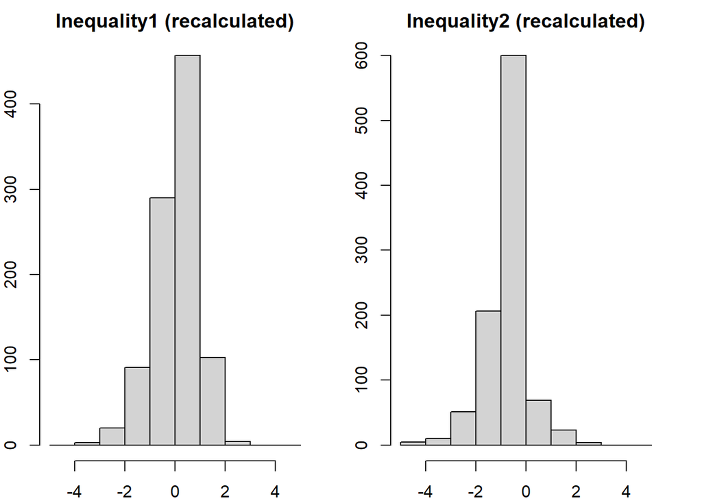

```r
 # Calculate Inequality2 (or Disparity 2) =(OrgEffLivelihood - OrgEffComm)
INEQ.outcomes$Inequality2_rec = as.numeric(INEQ.outcomes$OrgEffLivelihood) -
  as.numeric(INEQ.outcomes$OrgEffComm)

# check distribution of new response variables
par(mfrow = c(1,2),mar=c(2,2,2,2))
hist(INEQ.outcomes$Inequality1_rec,main="Inequality1 (recalculated)",
     breaks = c(-5,-4,-3,-2,-1,0,1,2,3,4,5))
hist(INEQ.outcomes$Inequality2_rec,main="Inequality2 (recalculated)",
     breaks = c(-5,-4,-3,-2,-1,0,1,2,3,4,5))
```

```r
INEQ=INEQ.outcomes
```

### Type of Disparity

```r
### Split Disparity1 data into losses (-5 to 0)  and gains (0 to 5)
# 1. Create binary variable: 0 for equal, 1 for any disparity
INEQ$Ineq1_bin <- as.integer(ifelse(INEQ$Inequality1_rec < 0.5 &  INEQ$Inequality1_rec > -0.5,0,1)
              )#transform to 0 values between 0.5 and -0.5 (equality), transform to 1 the rest


#2. Create categorical variable with type of disparity: "equal", "loss", "gain"
INEQ$Ineq1_bintype <- as.factor(ifelse(INEQ$Inequality1_rec < -0.5,"loss",
                                       ifelse(INEQ$Inequality1_rec>0.5,"gain","equal")))

### Split Disparity2 data into losses (-5 to 0)  and gains (0 to 5)
# 1. Create binary variable: 0 for equal, 1 for any disparity
INEQ$Ineq2_bin <- as.integer(ifelse(INEQ$Inequality2_rec == 0,0,1))
# 2. Create categorical variable with type of disparity: "equal", "loss", "gain"
INEQ$Ineq2_bintype <- as.factor(ifelse(INEQ$Inequality2_rec < 0,"loss",
                                       ifelse(INEQ$Inequality2_rec>0,"gain","equal")))
```

### Eliminate rest of don’t knows and NAs

```r
which(is.na(INEQ$trustleaders))
```

```
## [1] 597
```

```r
INEQ<-INEQ[-c(597),]#eliminate NAs

INEQ <- INEQ[INEQ$trustleaders!=0,] #Eliminate don't knows


which(is.na(INEQ$ yrseducation))
```

```
## [1] 906
```

```r
INEQ<-INEQ[-c(906),] #eliminate NAs


which(is.na(INEQ$migrant))
```

```
## [1] 913
```

```r
INEQ<-INEQ[-c(913),] #eliminate NAs

which(is.na(INEQ$ decispart ))
```

```
## [1] 237 485
```

```r
INEQ<-INEQ[-c(237,485),] #eliminate NAs
colSums(is.na(INEQ))
```

```
##                 site                 dbid             sampleid
##                    0                    0                    0
##             datatype              country     OrgEffLivelihood
##                    0                    0                    0
##           OrgEffComm                  sex         yrseducation
##                    0                    0                    0
##              migrant           marlivprim               occdiv
##                    0                    0                    0
##               mslall         trustleaders            decispart
##                    0                    0                    0
##            CommEvent                 popn           distmktreg
##                   34                    0                    0
##                 regr                 regg                 rega
##                    0                    0                    0
##      clearboundaries        confmechinter        GradSanctions
##                    0                    0                    0
## OrgEffLivelihood_cat       OrgEffComm_cat            avgeffliv
##                    0                    0                    0
##      Inequality1_rec      Inequality2_rec            Ineq1_bin
##                    0                    0                    0
##        Ineq1_bintype            Ineq2_bin        Ineq2_bintype
##                    0                    0                    0
```

```r
colSums(is.na(INEQ))
```

```
##                 site                 dbid             sampleid
##                    0                    0                    0
##             datatype              country     OrgEffLivelihood
##                    0                    0                    0
##           OrgEffComm                  sex         yrseducation
##                    0                    0                    0
##              migrant           marlivprim               occdiv
##                    0                    0                    0
##               mslall         trustleaders            decispart
##                    0                    0                    0
##            CommEvent                 popn           distmktreg
##                   34                    0                    0
##                 regr                 regg                 rega
##                    0                    0                    0
##      clearboundaries        confmechinter        GradSanctions
##                    0                    0                    0
## OrgEffLivelihood_cat       OrgEffComm_cat            avgeffliv
##                    0                    0                    0
##      Inequality1_rec      Inequality2_rec            Ineq1_bin
##                    0                    0                    0
##        Ineq1_bintype            Ineq2_bin        Ineq2_bintype
##                    0                    0                    0
```

```r
dim(INEQ)#955
```

```
## [1] 955  33
```

```r
#oultiers community events

boxplot(INEQ$CommEvent, plot=FALSE)$out  #Identify the outliers
```

```
##  [1]  2.648649  2.648649  3.027027  2.648649  3.205212  4.273616  3.154102
##  [8]  5.933763  2.736925  2.736925  4.273616  5.128339  3.205212  2.991531
## [15]  2.564169 10.684039  4.273616 10.684039  3.154102  4.352661  3.091020
## [22]  2.523282  3.154102  2.775610  3.154102  3.154102  3.193079  3.154102
## [29]  2.564169  3.205212  2.564169  2.736925 18.918919  2.648649  3.027027
## [36]  2.736925  2.736925  2.736925  2.554463  2.736925  3.154102  2.523282
## [43]  3.154102  2.964856  2.523282  3.154102  2.736925  2.736925  2.736925
## [50]  2.777850  4.747010  2.564169
```

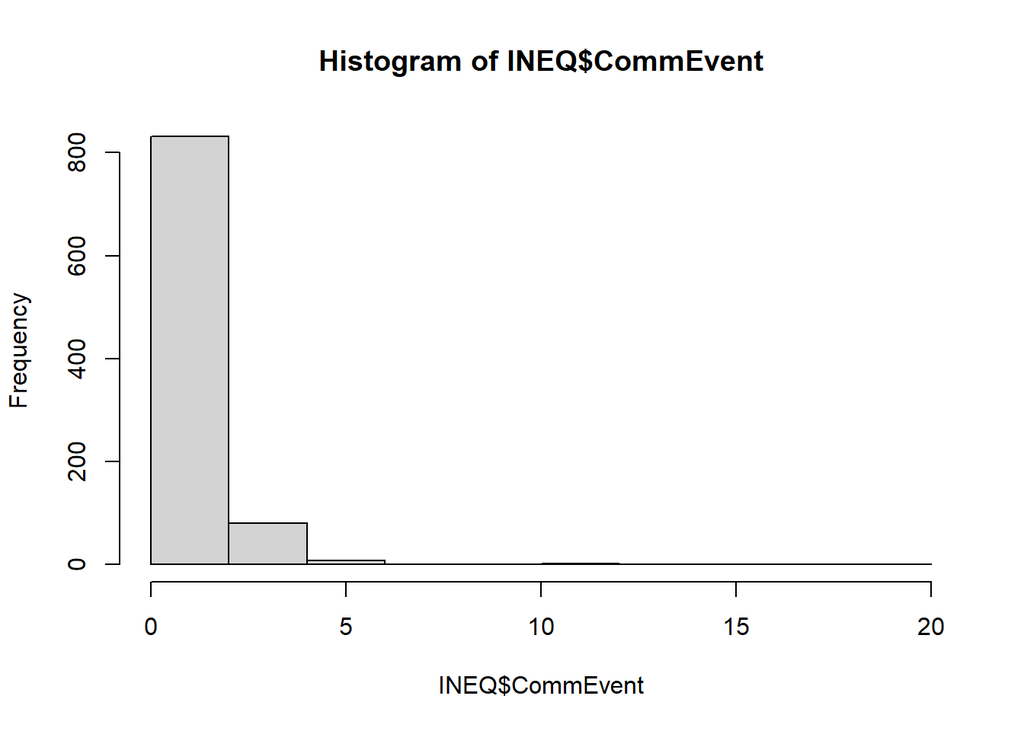

```r
hist(INEQ$CommEvent)
```

```r
which(is.na(INEQ$ CommEvent )) #Identify NAs in community events
```

```
##  [1]  99 207 210 213 214 215 217 218 220 231 250 257 379 403 404 406 408 409 410
## [20] 413 454 501 549 607 610 623 669 670 672 677 795 852 949 954
```

```r
INEQ<-INEQ[-c(99, 207, 210, 213, 214, 215, 217, 218, 220, 231, 250, 257, 379, 403, 404,
               406, 408, 409, 410, 413, 454, 501, 549, 607, 610, 623, 669, 670, 672, 677,
              795, 852, 949, 954),]  #eliminate NAs


colSums(is.na(INEQ))
```

```
##                 site                 dbid             sampleid
##                    0                    0                    0
##             datatype              country     OrgEffLivelihood
##                    0                    0                    0
##           OrgEffComm                  sex         yrseducation
##                    0                    0                    0
##              migrant           marlivprim               occdiv
##                    0                    0                    0
##               mslall         trustleaders            decispart
##                    0                    0                    0
##            CommEvent                 popn           distmktreg
##                    0                    0                    0
##                 regr                 regg                 rega
##                    0                    0                    0
##      clearboundaries        confmechinter        GradSanctions
##                    0                    0                    0
## OrgEffLivelihood_cat       OrgEffComm_cat            avgeffliv
##                    0                    0                    0
##      Inequality1_rec      Inequality2_rec            Ineq1_bin
##                    0                    0                    0
##        Ineq1_bintype            Ineq2_bin        Ineq2_bintype
##                    0                    0                    0
```

```r
INEQ<-subset(INEQ,CommEvent<18)#Eliminate this outlier. It is an error

dim(INEQ)#920
```

```
## [1] 920  33
```

```r
which(is.na(INEQ$ CommEvent ))
```

```
## integer(0)
```

### Define factors and standardize predictors

Define factors

```r
INEQ$decispart_cat <- as.factor(INEQ$decispart)
INEQ$sex_cat<-as.factor(INEQ$sex)
INEQ$site_cat<-as.factor(INEQ$site)
INEQ$migrant_cat<-as.factor(INEQ$migrant)
INEQ$marlivprim_cat<-as.factor(INEQ$marlivprim)
INEQ$regr_cat<-as.factor(INEQ$regr)
INEQ$regg_cat<-as.factor(INEQ$regg)
INEQ$rega_cat<-as.factor(INEQ$rega)
INEQ$GradSanctions_cat<-as.factor(INEQ$GradSanctions)
INEQ$clearboundaries_cat<-as.factor(INEQ$clearboundaries)
```

Standardize predictors

```r
#continuous

#standardize (2sd)
INEQ$distmktreg_sd<-scale(INEQ$distmktreg)*0.5
INEQ$popn_sd<-scale(INEQ$popn)*0.5
INEQ$yrseducation_sd<-scale(INEQ$yrseducation)*0.5
INEQ$mslall_sd<-scale(INEQ$mslall)*0.5
INEQ$occdiv_sd<-scale(INEQ$occdiv)*0.5
INEQ$CommEvent_sd<-scale(INEQ$CommEvent)*0.5
INEQ$trustleaders_sd<-scale(INEQ$trustleaders)*0.5
INEQ$confmechinter_sd<-scale(INEQ$confmechinter)*0.5
```

### Split data in 4

Split initial INEQ data set into 4 data sets that will be used in the models: losses and gains for Inequality 1 (actual) and Inequality 2 (perceived) The 4 data sets are: 1) INEQ_loss1 (for objective losses) 2) INEQ_gain1 (for objective gains) 3) INEQ_loss2 (for subjective losses) 4) INEQ_gain2 (for subjective gains)

```r
# LOSSES 1 (actual/objective): table containing only data for losses
#and equality for Inequality1 (disparity 1)

INEQ_loss1 <- INEQ[INEQ$Ineq1_bintype %in% c("loss","equal"),]
INEQ_loss1$site <- factor(INEQ_loss1$site)
INEQ_loss1$country <- factor(INEQ_loss1$country)

# GAINS 1 (actual): table containing only data for gains
#and equality for Inequality1 (disparity 1)
INEQ_gain1 <- INEQ[INEQ$Ineq1_bintype %in% c("gain","equal"),]
INEQ_gain1$site <- factor(INEQ_gain1$site)
INEQ_gain1$country <- factor(INEQ_gain1$country)


# LOSSES 2 (perceived): table containing only data for losses
#and equality for Inequality2 (disparity 2)
INEQ_loss2 <- INEQ[INEQ$Ineq2_bintype %in% c("loss","equal"),]
INEQ_loss2$site <- factor(INEQ_loss2$site)
INEQ_loss2$country <- factor(INEQ_loss2$country)
# GAINS 2 (perceived): table containing only data for gains
#and equality for Inequality2 (disparity 2)
INEQ_gain2 <- INEQ[INEQ$Ineq2_bintype %in% c("gain","equal"),]
INEQ_gain2$site <- factor(INEQ_gain2$site)
INEQ_gain2$country <- factor(INEQ_gain2$country)
```

### MODEL OBJECTIVE LOSSES (Disparity 1)

Define the global model

```r
M.loss1_global.model<-glmer(Ineq1_bin ~ migrant_cat+ sex_cat + yrseducation_sd +
                              trustleaders_sd +decispart_cat + marlivprim_cat +
                              mslall_sd + occdiv_sd + CommEvent_sd+
              popn_sd + distmktreg_sd  +  regr_cat + regg_cat + rega_cat +
              clearboundaries_cat  + confmechinter_sd + GradSanctions_cat +(1 | site_cat),
              data = INEQ_loss1,family=binomial(link = "logit"), na.action='na.fail',
              control = glmerControl(optimizer="bobyqa",optCtrl=list(maxfun=1000000)))
```

```r
summary(M.loss1_global.model)
```

```
## Generalized linear mixed model fit by maximum likelihood (Laplace
##   Approximation) [glmerMod]
##  Family: binomial  ( logit )
## Formula:
## Ineq1_bin ~ migrant_cat + sex_cat + yrseducation_sd + trustleaders_sd +
##     decispart_cat + marlivprim_cat + mslall_sd + occdiv_sd +
##     CommEvent_sd + popn_sd + distmktreg_sd + regr_cat + regg_cat +
##     rega_cat + clearboundaries_cat + confmechinter_sd + GradSanctions_cat +
##     (1 | site_cat)
##    Data: INEQ_loss1
## Control: glmerControl(optimizer = "bobyqa", optCtrl = list(maxfun = 1e+06))
##
##      AIC      BIC   logLik deviance df.resid
##    790.7    880.8   -375.3    750.7      650
##
## Scaled residuals:
##     Min      1Q  Median      3Q     Max
## -2.7786 -0.6043 -0.3383  0.7261  3.0061
##
## Random effects:
##  Groups   Name        Variance Std.Dev.
##  site_cat (Intercept) 1.695    1.302
## Number of obs: 670, groups:  site_cat, 47
##
## Fixed effects:
##                       Estimate Std. Error z value Pr(>|z|)
## (Intercept)          -0.001068   0.840220  -0.001 0.998985
## migrant_cat1          0.277207   0.412852   0.671 0.501938
## sex_catM             -0.175309   0.476396  -0.368 0.712880
## yrseducation_sd      -0.030168   0.217163  -0.139 0.889516
## trustleaders_sd       0.279245   0.204582   1.365 0.172267
## decispart_cat1       -0.786738   0.297836  -2.642 0.008254 **
## decispart_cat2       -1.016430   0.275585  -3.688 0.000226 ***
## marlivprim_cat1      -0.485853   0.287127  -1.692 0.090624 .
## mslall_sd            -0.151454   0.347532  -0.436 0.662983
## occdiv_sd            -0.171685   0.281999  -0.609 0.542647
## CommEvent_sd          0.484582   0.227075   2.134 0.032841 *
## popn_sd              -1.178851   0.591258  -1.994 0.046174 *
## distmktreg_sd         0.320699   0.409207   0.784 0.433211
## regr_cat1            -2.139454   0.675588  -3.167 0.001541 **
## regg_cat1             1.204969   0.709896   1.697 0.089623 .
## rega_cat1             0.392067   0.569423   0.689 0.491117
## clearboundaries_cat1 -0.297213   0.514986  -0.577 0.563852
## confmechinter_sd      0.488268   0.485464   1.006 0.314523
## GradSanctions_cat1    0.663163   0.536663   1.236 0.216564
## ---
## Signif. codes:  0 '***' 0.001 '**' 0.01 '*' 0.05 '.' 0.1 ' ' 1
```

```
##
## Correlation matrix not shown by default, as p = 19 > 12.
## Use print(x, correlation=TRUE)  or
##     vcov(x)        if you need it
```

```r
vif(M.loss1_global.model)
```

```
##                         GVIF Df GVIF^(1/(2*Df))
## migrant_cat         1.058065  1        1.028623
## sex_cat             1.047986  1        1.023712
## yrseducation_sd     1.062701  1        1.030874
## trustleaders_sd     1.041249  1        1.020416
## decispart_cat       1.103221  2        1.024863
## marlivprim_cat      1.107630  1        1.052440
## mslall_sd           1.285081  1        1.133614
## occdiv_sd           1.160308  1        1.077176
## CommEvent_sd        1.045756  1        1.022622
## popn_sd             1.432817  1        1.197003
## distmktreg_sd       1.241261  1        1.114119
## regr_cat            1.355431  1        1.164230
## regg_cat            1.843736  1        1.357843
## rega_cat            1.589977  1        1.260943
## clearboundaries_cat 1.292948  1        1.137079
## confmechinter_sd    1.138007  1        1.066774
## GradSanctions_cat   1.362081  1        1.167082
```

We can conclude there is not multicollinearity

```r
check_overdispersion(M.loss1_global.model)
```

```
## # Overdispersion test
##
##        dispersion ratio =   0.835
##   Pearson's Chi-Squared = 542.564
##                 p-value =   0.999
```

```
## No overdispersion detected.
```

```r
check_singularity(M.loss1_global.model)#singularity is fine
```

```
## [1] FALSE
```

```r
check_convergence(M.loss1_global.model)#convergence is fine
```

```
## [1] TRUE
## attr(,"gradient")
## [1] 3.129966e-06
```

Dharma residuals

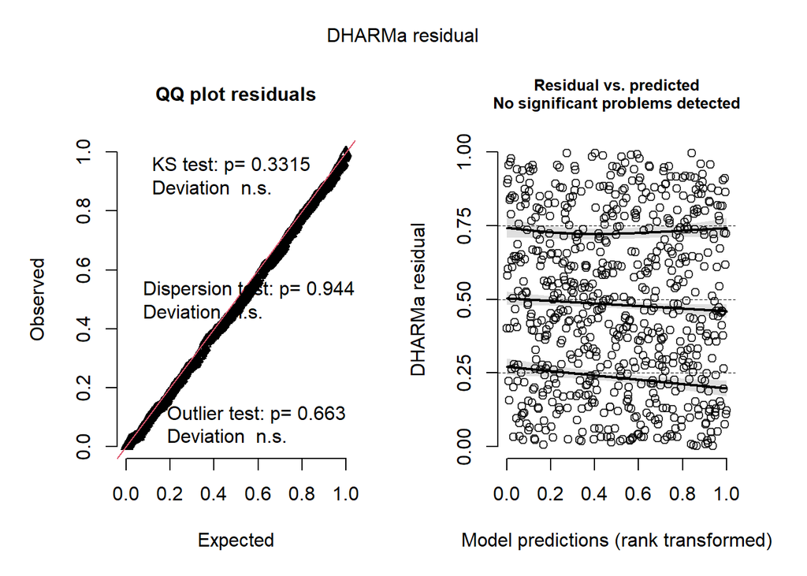

```r
resid.loss1=simulateResiduals(M.loss1_global.model, plot=TRUE)
```

```r
#loss1.dredge<-dredge(global.model = M.loss1_global.model, trace = TRUE)#This line of code was
#run on the HPC of James Cook University. It will take a long time to run.
#Consider running this code in your own computer.
```

Load dredge output

```r
loss1.2_dredge_sd<-readRDS(file="loss1.2.dredge.sd.rds")
```

Model average

```r
loss1.average_sd<-summary(model.avg(loss1.2_dredge_sd, subset = delta <= 2))
```

```r
loss1.average_sd
```

```
##
## Call:
## model.avg(object = loss1.2_dredge_sd, subset = delta <= 2)
##
## Component model call:
## glmer(formula = Ineq1_bin ~ <26 unique rhs>, data = INEQ_loss1, family
##      = binomial(link = "logit"), control = glmerControl(optimizer =
##      "bobyqa", optCtrl = list(maxfun = 1e+06)), na.action = na.fail)
##
## Component models:
##                       df  logLik   AICc delta weight
## 1+5+7+10+12+13         9 -378.93 776.13  0.00   0.07
## 1+5+7+10+12+13+14     10 -377.95 776.23  0.10   0.07
## 1+3+5+7+10+12+13      10 -378.15 776.64  0.51   0.05
## 1+5+10+12+13           8 -380.23 776.68  0.55   0.05
## 1+3+5+7+10+12+13+14   11 -377.19 776.77  0.64   0.05
## 1+2+5+7+10+12+13      10 -378.28 776.90  0.77   0.05
## 1+5+10+12+13+14        9 -379.32 776.91  0.78   0.05
## 1+2+5+7+10+12+13+14   11 -377.31 777.01  0.88   0.04
## 1+3+5+10+12+13         9 -379.48 777.23  1.10   0.04
## 1+2+5+10+12+13         9 -379.58 777.42  1.29   0.04
## 1+4+5+7+10+12+13      10 -378.54 777.42  1.29   0.04
## 1+3+5+10+12+13+14     10 -378.58 777.50  1.37   0.03
## 1+4+5+7+10+12+13+14   11 -377.56 777.52  1.39   0.03
## 1+5+6+7+10+12+13      10 -378.65 777.63  1.50   0.03
## 1+5+7+9+10+12+13      10 -378.67 777.67  1.54   0.03
## 1+2+5+10+12+13+14     10 -378.67 777.67  1.54   0.03
## 1+5+6+7+10+12+13+14   11 -377.66 777.72  1.59   0.03
## 1+4+5+10+12+13         9 -379.74 777.75  1.62   0.03
## 1+2+3+5+7+10+12+13    11 -377.68 777.77  1.64   0.03
## 1+5+7+9+10+12+13+14   11 -377.69 777.79  1.66   0.03
## 1+5+7+8+10+12+13      10 -378.74 777.81  1.68   0.03
## 1+2+3+5+7+10+12+13+14 12 -376.72 777.92  1.79   0.03
## 1+5+7+10+11+12+13     10 -378.81 777.95  1.82   0.03
## 1+4+5+10+12+13+14     10 -378.82 777.98  1.85   0.03
## 1+5+7+8+10+12+13+14   11 -377.80 778.00  1.87   0.03
## 1+5+7+10+11+12+13+14  11 -377.85 778.10  1.97   0.03
##
## Term codes:
##        CommEvent_sd   GradSanctions_cat clearboundaries_cat    confmechinter_sd
```

[output cut: 33 more lines]

```
## decispart_cat2        -1.0334     0.2734      0.2739   3.772 0.000162 ***
## marlivprim_cat1       -0.4631     0.2804      0.2810   1.648 0.099300 .
## popn_sd               -1.2790     0.5901      0.5912   2.163 0.030516 *
## regg_cat1              1.6341     0.6431      0.6443   2.536 0.011200 *
## regr_cat1             -2.1807     0.6682      0.6694   3.258 0.001123 **
## trustleaders_sd        0.2888     0.2087      0.2091   1.381 0.167273
## clearboundaries_cat1  -0.5802     0.4770      0.4779   1.214 0.224757
## GradSanctions_cat1     0.5670     0.5134      0.5143   1.102 0.270322
## confmechinter_sd       0.4587     0.4915      0.4924   0.932 0.351549
## distmktreg_sd          0.2981     0.3924      0.3932   0.758 0.448317
## occdiv_sd             -0.2106     0.2883      0.2889   0.729 0.465945
## migrant_cat1           0.2375     0.4064      0.4071   0.584 0.559545
## rega_cat1              0.2550     0.5427      0.5437   0.469 0.639047
## ---
## Signif. codes:  0 '***' 0.001 '**' 0.01 '*' 0.05 '.' 0.1 ' ' 1
```

Relative influence

```r
sw(loss1.average_sd)#Sum of model weights over all models including each explanatory variable.
```

```
##                      CommEvent_sd decispart_cat popn_sd regg_cat regr_cat
## Sum of weights:      1.00         1.00          1.00    1.00     1.00
## N containing models:   26           26            26      26       26
##                      marlivprim_cat trustleaders_sd clearboundaries_cat
## Sum of weights:      0.70           0.48            0.24
## N containing models:   18             13               6
##                      GradSanctions_cat confmechinter_sd distmktreg_sd occdiv_sd
## Sum of weights:      0.22              0.13             0.06          0.06
## N containing models:    6                 4                2             2
##                      migrant_cat rega_cat
## Sum of weights:      0.06        0.05
## N containing models:    2           2
```

Confident intervals of the full model

```r
confint(loss1.average_sd,full=T,level=0.9) #full model averages
```

```
##                              5 %       95 %
## (Intercept)          -1.19104579  0.9220230
## CommEvent_sd          0.09366994  0.8481576
## decispart_cat1       -1.25942311 -0.2856242
## decispart_cat2       -1.48377739 -0.5829792
## marlivprim_cat1      -0.84430315  0.1972955
## popn_sd              -2.25099543 -0.3069369
## regg_cat1             0.57483656  2.6933723
## regr_cat1            -3.28123020 -1.0800713
## trustleaders_sd      -0.19759915  0.4750408
## clearboundaries_cat1 -0.69668887  0.4205711
## GradSanctions_cat1   -0.42859548  0.6772734
## confmechinter_sd     -0.32649574  0.4451454
## distmktreg_sd        -0.18381953  0.2220044
## occdiv_sd            -0.15842986  0.1321318
## migrant_cat1         -0.17035806  0.1975117
## rega_cat1            -0.21411910  0.2415335
```

```r
ma.loss1<-summary(loss1.average_sd)#pulling out model averages
```

```r
df.loss1<-as.data.frame(ma.loss1$coefmat.full)#selecting full model coefficient averages
```

```r
CI<-as.data.frame(confint(loss1.average_sd,level=0.9,full=T))# to get confident intervals
#for full model
```

```r
CI
```

```
##                              5 %       95 %
## (Intercept)          -1.19104579  0.9220230
## CommEvent_sd          0.09366994  0.8481576
## decispart_cat1       -1.25942311 -0.2856242
## decispart_cat2       -1.48377739 -0.5829792
## marlivprim_cat1      -0.84430315  0.1972955
## popn_sd              -2.25099543 -0.3069369
## regg_cat1             0.57483656  2.6933723
## regr_cat1            -3.28123020 -1.0800713
## trustleaders_sd      -0.19759915  0.4750408
## clearboundaries_cat1 -0.69668887  0.4205711
## GradSanctions_cat1   -0.42859548  0.6772734
## confmechinter_sd     -0.32649574  0.4451454
## distmktreg_sd        -0.18381953  0.2220044
## occdiv_sd            -0.15842986  0.1321318
## migrant_cat1         -0.17035806  0.1975117
## rega_cat1            -0.21411910  0.2415335
```

```r
df.loss1$CI.min <-CI$`5 %` #pulling out CIs and putting into same df as coefficient estimates
```

```r
df.loss1$CI.max <-CI$`95 %`
```

```r
library('data.table')
df.loss1
```

```
##                         Estimate Std. Error Adjusted SE    z value  Pr(>|z|)
## (Intercept)          -0.13451139 0.64155579  0.64256424 0.20933532 0.8341865
## CommEvent_sd          0.47091376 0.22902640  0.22944669 2.05238854 0.0401319
## decispart_cat1       -0.77252365 0.29560354  0.29613984 2.60864476 0.0090902
## decispart_cat2       -1.03337830 0.27344687  0.27393876 3.77229674 0.0001618
## marlivprim_cat1      -0.32350384 0.31637982  0.31669836 1.02148885 0.3070229
## popn_sd              -1.27896617 0.59013595  0.59120236 2.16333063 0.0305158
## regg_cat1             1.63410445 0.64310565  0.64426044 2.53640353 0.0111998
## regr_cat1            -2.18065075 0.66817069  0.66939162 3.25766067 0.0011233
## trustleaders_sd       0.13872083 0.20432398  0.20451229 0.67830074 0.4975810
## clearboundaries_cat1 -0.13805888 0.33939933  0.33969161 0.40642417 0.6844310
## GradSanctions_cat1    0.12433897 0.33591963  0.33623420 0.36979869 0.7115325
## confmechinter_sd      0.05932481 0.23437528  0.23461967 0.25285524 0.8003801
## distmktreg_sd         0.01909246 0.12324913  0.12339631 0.15472469 0.8770384
## occdiv_sd            -0.01314904 0.08824171  0.08834988 0.14882914 0.8816885
## migrant_cat1          0.01357684 0.11170575  0.11186094 0.12137247 0.9033960
## rega_cat1             0.01370718 0.13834763  0.13855796 0.09892738 0.9211959
##                           CI.min     CI.max
## (Intercept)          -1.19104579  0.9220230
## CommEvent_sd          0.09366994  0.8481576
## decispart_cat1       -1.25942311 -0.2856242
## decispart_cat2       -1.48377739 -0.5829792
## marlivprim_cat1      -0.84430315  0.1972955
## popn_sd              -2.25099543 -0.3069369
## regg_cat1             0.57483656  2.6933723
## regr_cat1            -3.28123020 -1.0800713
## trustleaders_sd      -0.19759915  0.4750408
## clearboundaries_cat1 -0.69668887  0.4205711
## GradSanctions_cat1   -0.42859548  0.6772734
## confmechinter_sd     -0.32649574  0.4451454
## distmktreg_sd        -0.18381953  0.2220044
## occdiv_sd            -0.15842986  0.1321318
## migrant_cat1         -0.17035806  0.1975117
## rega_cat1            -0.21411910  0.2415335
```

```r
setDT(df.loss1, keep.rownames='coefficient')#put row names into columns
```

```r
names(df.loss1) <- gsub(" ",'',names(df.loss1))#remove spaces from column headers
```

Plot standardized effects

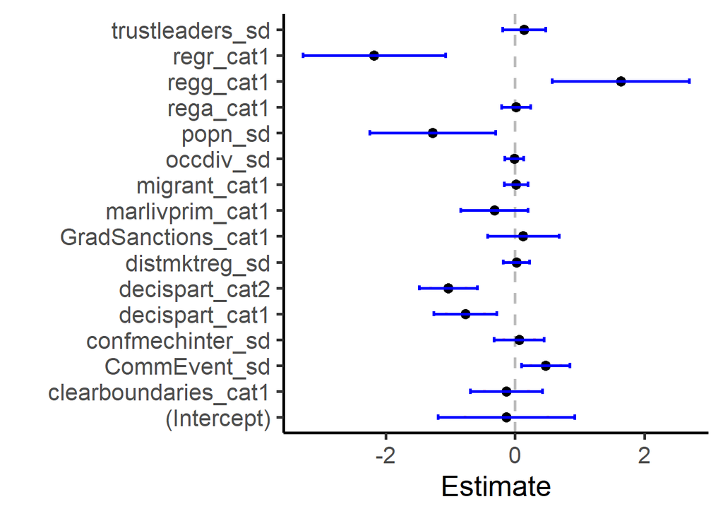

```r
ggplot(data=df.loss1, aes(x=coefficient, y=Estimate))+
  geom_hline(yintercept=0, color='grey', linetype='dashed', lwd=1)+
  geom_errorbar(aes(ymin=Estimate-Std.Error, ymax=Estimate+Std.Error), colour="pink",#SE
         width=.1, lwd=1)+
    coord_flip()+
    geom_point(size=3)+theme_classic(base_size=20)+xlab("")+
  geom_errorbar(aes(ymin=CI.min, ymax=CI.max), colour="blue", # CIs
                width=.2,lwd=1)
```

### MODEL OBJECTIVE GAINS (Disparity 1)

Define global model

```r
M.gains1_global.model<-glmer(Ineq1_bin ~ migrant_cat+ sex_cat + yrseducation_sd +
 trustleaders_sd + decispart_cat + marlivprim_cat + mslall_sd + occdiv_sd + CommEvent_sd+
   popn_sd + distmktreg_sd  +  regr_cat + regg_cat + rega_cat +
clearboundaries_cat  + confmechinter_sd + GradSanctions_cat +(1 | site_cat),
                    data = INEQ_gain1,family=binomial(link = "logit"), na.action='na.fail',
                    control = glmerControl(optimizer="bobyqa",optCtrl=list(maxfun=1000000)))
```

```r
summary(M.gains1_global.model)
```

```
## Generalized linear mixed model fit by maximum likelihood (Laplace
##   Approximation) [glmerMod]
##  Family: binomial  ( logit )
## Formula:
## Ineq1_bin ~ migrant_cat + sex_cat + yrseducation_sd + trustleaders_sd +
##     decispart_cat + marlivprim_cat + mslall_sd + occdiv_sd +
##     CommEvent_sd + popn_sd + distmktreg_sd + regr_cat + regg_cat +
##     rega_cat + clearboundaries_cat + confmechinter_sd + GradSanctions_cat +
##     (1 | site_cat)
##    Data: INEQ_gain1
## Control: glmerControl(optimizer = "bobyqa", optCtrl = list(maxfun = 1e+06))
##
##      AIC      BIC   logLik deviance df.resid
##    724.0    814.1   -342.0    684.0      651
##
## Scaled residuals:
##     Min      1Q  Median      3Q     Max
## -3.0320 -0.5639 -0.1804  0.5585  2.9540
##
## Random effects:
##  Groups   Name        Variance Std.Dev.
##  site_cat (Intercept) 3.713    1.927
## Number of obs: 671, groups:  site_cat, 47
##
## Fixed effects:
##                      Estimate Std. Error z value Pr(>|z|)
## (Intercept)          -0.80617    1.06821  -0.755   0.4504
## migrant_cat1         -0.11685    0.43052  -0.271   0.7861
## sex_catM             -0.42489    0.51688  -0.822   0.4111
## yrseducation_sd       0.10765    0.22925   0.470   0.6387
## trustleaders_sd       0.36568    0.23111   1.582   0.1136
## decispart_cat1        0.07891    0.31043   0.254   0.7993
## decispart_cat2       -0.30516    0.29983  -1.018   0.3088
## marlivprim_cat1      -0.29669    0.31637  -0.938   0.3483
## mslall_sd             0.27085    0.34773   0.779   0.4360
## occdiv_sd             0.20746    0.29765   0.697   0.4858
## CommEvent_sd         -0.16413    0.25176  -0.652   0.5144
## popn_sd              -0.82336    0.80211  -1.026   0.3047
## distmktreg_sd         0.50535    0.56425   0.896   0.3705
## regr_cat1            -1.69247    0.86598  -1.954   0.0507 .
## regg_cat1             0.78121    0.95756   0.816   0.4146
## rega_cat1             0.69590    0.76365   0.911   0.3621
## clearboundaries_cat1  0.03733    0.69756   0.054   0.9573
## confmechinter_sd      0.96005    0.67999   1.412   0.1580
## GradSanctions_cat1    0.95870    0.72695   1.319   0.1872
## ---
## Signif. codes:  0 '***' 0.001 '**' 0.01 '*' 0.05 '.' 0.1 ' ' 1
```

```
##
## Correlation matrix not shown by default, as p = 19 > 12.
## Use print(x, correlation=TRUE)  or
##     vcov(x)        if you need it
```

```r
check_overdispersion(M.gains1_global.model)
```

```
## # Overdispersion test
##
##        dispersion ratio =   0.750
##   Pearson's Chi-Squared = 488.179
##                 p-value =       1
```

```
## No overdispersion detected.
```

```r
check_singularity(M.gains1_global.model)
```

```
## [1] FALSE
```

```r
check_convergence(M.gains1_global.model)
```

```
## [1] TRUE
## attr(,"gradient")
## [1] 6.824324e-06
```

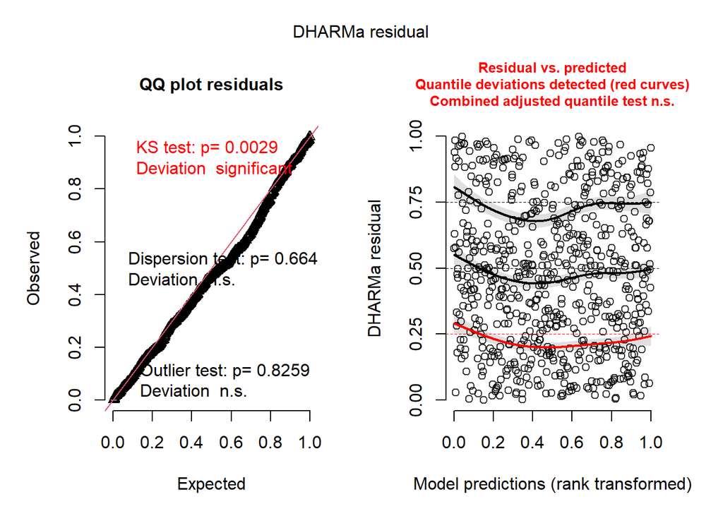

```r
resid.gains1=simulateResiduals(M.gains1_global.model, plot=TRUE)
```

Although diagnostics showed minor problems with the deviation, they are known to be very sensitive with large data sets. Visually, the evaluation does not show any major problem

```r
vif(M.gains1_global.model)
```

```
##                         GVIF Df GVIF^(1/(2*Df))
## migrant_cat         1.041859  1        1.020715
## sex_cat             1.026230  1        1.013030
## yrseducation_sd     1.101419  1        1.049485
## trustleaders_sd     1.039803  1        1.019707
## decispart_cat       1.105651  2        1.025426
## marlivprim_cat      1.090304  1        1.044176
## mslall_sd           1.194955  1        1.093140
## occdiv_sd           1.110375  1        1.053743
## CommEvent_sd        1.071672  1        1.035216
## popn_sd             1.273856  1        1.128652
## distmktreg_sd       1.238654  1        1.112948
## regr_cat            1.271643  1        1.127671
## regg_cat            1.733880  1        1.316769
## rega_cat            1.488955  1        1.220227
## clearboundaries_cat 1.230416  1        1.109241
## confmechinter_sd    1.105343  1        1.051353
## GradSanctions_cat   1.300527  1        1.140406
```

```r
#gains1.dredge<-dredge(global.model = M.gains1_global.model, trace = TRUE)#This line of
#code was run on the HPC of James Cook University. It will take a long time to run.
#Consider running this code in your own computer.
```

Load dredge object

```r
gains1.2_dredge_sd<-readRDS(file="gains1.2.dredge.sd.rds")
```

Model average

```r
gains1.average_sd<-summary(model.avg(gains1.2_dredge_sd, subset = delta <= 2))
```

```r
gains1.average_sd
```

```
##
## Call:
## model.avg(object = gains1.2_dredge_sd, subset = delta <= 2)
##
## Component model call:
## glmer(formula = Ineq1_bin ~ <384 unique rhs>, data = INEQ_gain1, family
##      = binomial(link = "logit"), control = glmerControl(optimizer =
##      "bobyqa", optCtrl = list(maxfun = 1e+06)), na.action = na.fail)
##
## Component models:
##                    df  logLik   AICc delta weight
## 2+13                4 -349.71 707.48  0.00   0.01
## 2+13+15             5 -348.70 707.50  0.02   0.01
## 2+7+13+15           6 -347.69 707.50  0.03   0.01
## 12+13+15            5 -348.71 707.51  0.03   0.01
## 4+12+13+15          6 -347.71 707.55  0.07   0.01
## 4+10+12+13+15       7 -346.70 707.57  0.09   0.00
## 4+12+13             5 -348.77 707.63  0.15   0.00
## 4+10+12+13          6 -347.77 707.67  0.19   0.00
## 12+13               4 -349.82 707.69  0.21   0.00
## 2+4+13              5 -348.83 707.75  0.27   0.00
## 10+12+13+15         6 -347.84 707.81  0.33   0.00
## 7+12+13+15          6 -347.85 707.82  0.34   0.00
## 2+7+13              5 -348.87 707.83  0.35   0.00
## 13+15               4 -349.89 707.85  0.37   0.00
## 4+13                4 -349.90 707.85  0.37   0.00
## 2+4+13+15           6 -347.87 707.87  0.39   0.00
## 13                  3 -350.92 707.87  0.39   0.00
## 4+7+12+13+15        7 -346.85 707.87  0.39   0.00
## 2+4+7+13+15         7 -346.86 707.88  0.40   0.00
## 2+11+13             5 -348.90 707.90  0.42   0.00
## 7+13+15             5 -348.91 707.92  0.44   0.00
## 4+13+15             5 -348.92 707.93  0.45   0.00
## 2+15                4 -349.96 707.98  0.50   0.00
## 2+11+13+15          6 -347.93 707.98  0.51   0.00
## 4+15                4 -349.97 707.99  0.51   0.00
## 2+4                 4 -349.97 708.00  0.53   0.00
## 4                   3 -350.99 708.01  0.53   0.00
## 4+7+13+15           6 -347.94 708.01  0.53   0.00
## 10+12+13            5 -348.96 708.01  0.53   0.00
```

[output cut: 395 more lines]

```
## regg_cat1             1.26750    0.84647     0.84789   1.495   0.1349
## confmechinter_sd      0.96573    0.66241     0.66360   1.455   0.1456
## popn_sd              -0.98337    0.79167     0.79305   1.240   0.2150
## rega_cat1             0.80130    0.69467     0.69589   1.151   0.2495
## occdiv_sd             0.31173    0.29761     0.29815   1.046   0.2958
## decispart_cat1        0.09782    0.30553     0.30609   0.320   0.7493
## decispart_cat2       -0.29823    0.28857     0.28910   1.032   0.3023
## distmktreg_sd         0.51475    0.50587     0.50675   1.016   0.3097
## sex_catM             -0.48302    0.51485     0.51578   0.936   0.3490
## mslall_sd             0.29411    0.32802     0.32860   0.895   0.3708
## CommEvent_sd         -0.17739    0.20717     0.20755   0.855   0.3927
## clearboundaries_cat1 -0.49173    0.65291     0.65410   0.752   0.4522
## yrseducation_sd       0.13914    0.21883     0.21923   0.635   0.5256
## ---
## Signif. codes:  0 '***' 0.001 '**' 0.01 '*' 0.05 '.' 0.1 ' ' 1
```

Relative influence

```r
sw(gains1.average_sd)
```

```
##                      regr_cat trustleaders_sd confmechinter_sd
## Sum of weights:      0.81     0.56            0.49
## N containing models:  308      216             185
##                      GradSanctions_cat regg_cat marlivprim_cat popn_sd rega_cat
## Sum of weights:      0.48              0.35     0.31           0.20    0.14
## N containing models:  184               132      118             77      57
##                      occdiv_sd distmktreg_sd decispart_cat CommEvent_sd sex_cat
## Sum of weights:      0.12      0.12          0.10          0.09         0.08
## N containing models:   50        50            44            41           36
##                      mslall_sd clearboundaries_cat yrseducation_sd
## Sum of weights:      0.07      0.04                0.03
## N containing models:   32        19                  14
```

```r
confint(gains1.average_sd,full=T,level=0.9) #full model averages
```

```
##                              5 %       95 %
## (Intercept)          -1.86362129 0.64546790
## GradSanctions_cat1   -0.64811257 1.63983613
## regr_cat1            -2.79675534 0.38454066
## trustleaders_sd      -0.20369167 0.59085127
## marlivprim_cat1      -0.54019536 0.29133583
## regg_cat1            -0.84831974 1.72933054
## confmechinter_sd     -0.63039849 1.56780672
## popn_sd              -1.05776141 0.67120336
## rega_cat1            -0.51171701 0.73282183
## occdiv_sd            -0.20189431 0.27814099
## decispart_cat1       -0.15938814 0.17973325
## decispart_cat2       -0.24529849 0.18326956
## distmktreg_sd        -0.33758494 0.46171805
## sex_catM             -0.37230823 0.29049966
## mslall_sd            -0.17099337 0.21377203
## CommEvent_sd         -0.14810187 0.11616065
## clearboundaries_cat1 -0.29518786 0.25365352
## yrseducation_sd      -0.06890069 0.07710551
```

```r
ma.gains1<-summary(gains1.average_sd)#pulling out model averages
```

```r
df.gains1<-as.data.frame(ma.gains1$coefmat.full)#selecting full model coefficient averages
```

```r
CI<-as.data.frame(confint(gains1.average_sd,level=0.9,full=T))# to get confident intervals
#for full model
```

```r
CI
```

```
##                              5 %       95 %
## (Intercept)          -1.86362129 0.64546790
## GradSanctions_cat1   -0.64811257 1.63983613
## regr_cat1            -2.79675534 0.38454066
## trustleaders_sd      -0.20369167 0.59085127
## marlivprim_cat1      -0.54019536 0.29133583
## regg_cat1            -0.84831974 1.72933054
## confmechinter_sd     -0.63039849 1.56780672
## popn_sd              -1.05776141 0.67120336
## rega_cat1            -0.51171701 0.73282183
## occdiv_sd            -0.20189431 0.27814099
## decispart_cat1       -0.15938814 0.17973325
## decispart_cat2       -0.24529849 0.18326956
## distmktreg_sd        -0.33758494 0.46171805
## sex_catM             -0.37230823 0.29049966
## mslall_sd            -0.17099337 0.21377203
## CommEvent_sd         -0.14810187 0.11616065
## clearboundaries_cat1 -0.29518786 0.25365352
## yrseducation_sd      -0.06890069 0.07710551
```

```r
df.gains1$CI.min <-CI$`5 %` #pulling out CIs and putting into same df as coefficient estimates
```

```r
df.gains1$CI.max <-CI$`95 %`
```

```r
df.gains1
```

```
##                          Estimate Std. Error Adjusted SE    z value  Pr(>|z|)
## (Intercept)          -0.609076692 0.76203361  0.76291639 0.79835313 0.4246656
## GradSanctions_cat1    0.495861784 0.69506313  0.69561725 0.71283711 0.4759466
## regr_cat1            -1.206107339 0.96625735  0.96728736 1.24689662 0.2124354
## trustleaders_sd       0.193579798 0.24135567  0.24157558 0.80132187 0.4229453
## marlivprim_cat1      -0.124429767 0.25261062  0.25281574 0.49217572 0.6225951
## regg_cat1             0.440505403 0.78314149  0.78367557 0.56210174 0.5740467
## confmechinter_sd      0.468704113 0.66776920  0.66834141 0.70129444 0.4831193
## popn_sd              -0.193279028 0.52525509  0.52566409 0.36768543 0.7131078
## rega_cat1             0.110552413 0.37807641  0.37838561 0.29216865 0.7701577
## occdiv_sd             0.038123340 0.14581791  0.14595185 0.26120492 0.7939345
## decispart_cat1        0.010172554 0.10295418  0.10312593 0.09864205 0.9214225
## decispart_cat2       -0.031014467 0.13018327  0.13030375 0.23801669 0.8118682
## distmktreg_sd         0.062066556 0.24280202  0.24302272 0.25539405 0.7984188
## sex_catM             -0.040904286 0.20132423  0.20152692 0.20297182 0.8391571
## mslall_sd             0.021389330 0.11686905  0.11698843 0.18283287 0.8549292
## CommEvent_sd         -0.015970609 0.08026328  0.08035063 0.19876147 0.8424493
## clearboundaries_cat1 -0.020767169 0.16668642  0.16688185 0.12444235 0.9009650
## yrseducation_sd       0.004102408 0.04433849  0.04439632 0.09240423 0.9263769
##                           CI.min     CI.max
## (Intercept)          -1.86362129 0.64546790
## GradSanctions_cat1   -0.64811257 1.63983613
## regr_cat1            -2.79675534 0.38454066
## trustleaders_sd      -0.20369167 0.59085127
## marlivprim_cat1      -0.54019536 0.29133583
## regg_cat1            -0.84831974 1.72933054
## confmechinter_sd     -0.63039849 1.56780672
## popn_sd              -1.05776141 0.67120336
## rega_cat1            -0.51171701 0.73282183
## occdiv_sd            -0.20189431 0.27814099
## decispart_cat1       -0.15938814 0.17973325
## decispart_cat2       -0.24529849 0.18326956
## distmktreg_sd        -0.33758494 0.46171805
## sex_catM             -0.37230823 0.29049966
## mslall_sd            -0.17099337 0.21377203
## CommEvent_sd         -0.14810187 0.11616065
## clearboundaries_cat1 -0.29518786 0.25365352
## yrseducation_sd      -0.06890069 0.07710551
```

```r
setDT(df.gains1, keep.rownames='coefficient')#put row names into columns
```

```r
names(df.gains1) <- gsub(" ",'',names(df.gains1))#remove spaces from column headers
```

Plot standardized effects

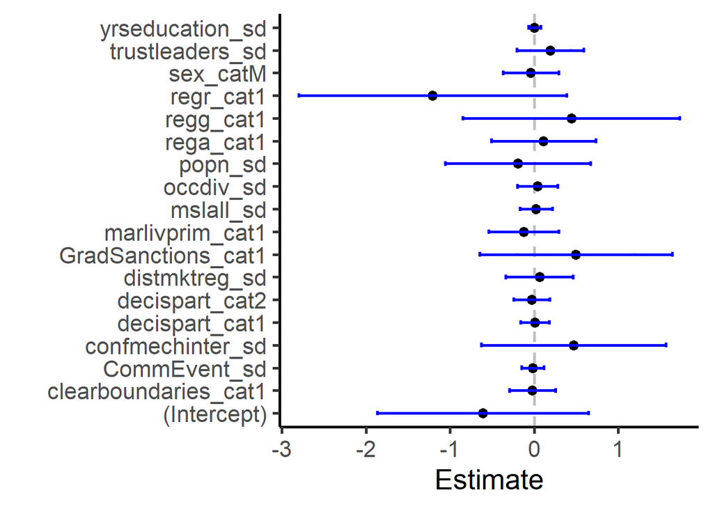

```r
ggplot(data=df.gains1, aes(x=coefficient, y=Estimate))+
  geom_hline(yintercept=0, color='grey', linetype='dashed', lwd=1)+
  geom_errorbar(aes(ymin=Estimate-Std.Error, ymax=Estimate+Std.Error), colour="pink",#SE
         width=.1, lwd=1)+
    coord_flip()+
    geom_point(size=3)+theme_classic(base_size=20)+xlab("")+
  geom_errorbar(aes(ymin=CI.min, ymax=CI.max), colour="blue", # CIs
                width=.2,lwd=1)
```

### MODEL SUBJECTIVE LOSSES (Disparity 2)

Global model

```r
M.loss2_global.model<-glmer(Ineq2_bin ~ migrant_cat+ sex_cat + yrseducation_sd +
    trustleaders_sd + decispart_cat + marlivprim_cat + mslall_sd + occdiv_sd +
     CommEvent_sd+ popn_sd + distmktreg_sd  +  regr_cat + regg_cat +
      rega_cat + clearboundaries_cat  + confmechinter_sd + GradSanctions_cat +
         (1 | site_cat), data = INEQ_loss2,family=binomial(link = "logit"),
          na.action='na.fail',control = glmerControl(optimizer="bobyqa",
              optCtrl=list(maxfun=1000000)))
```

```r
summary(M.loss2_global.model)
```

```
## Generalized linear mixed model fit by maximum likelihood (Laplace
##   Approximation) [glmerMod]
##  Family: binomial  ( logit )
## Formula:
## Ineq2_bin ~ migrant_cat + sex_cat + yrseducation_sd + trustleaders_sd +
##     decispart_cat + marlivprim_cat + mslall_sd + occdiv_sd +
##     CommEvent_sd + popn_sd + distmktreg_sd + regr_cat + regg_cat +
##     rega_cat + clearboundaries_cat + confmechinter_sd + GradSanctions_cat +
##     (1 | site_cat)
##    Data: INEQ_loss2
## Control: glmerControl(optimizer = "bobyqa", optCtrl = list(maxfun = 1e+06))
##
##      AIC      BIC   logLik deviance df.resid
##    941.4   1035.8   -450.7    901.4      808
##
## Scaled residuals:
##     Min      1Q  Median      3Q     Max
## -1.9062 -0.5958 -0.4329  0.7153  4.1493
##
## Random effects:
##  Groups   Name        Variance Std.Dev.
##  site_cat (Intercept) 0.2025   0.45
## Number of obs: 828, groups:  site_cat, 47
##
## Fixed effects:
##                      Estimate Std. Error z value Pr(>|z|)
## (Intercept)          -0.57596    0.57497  -1.002  0.31647
## migrant_cat1          0.24940    0.33760   0.739  0.46006
## sex_catM              0.70237    0.43604   1.611  0.10723
## yrseducation_sd       0.06809    0.18589   0.366  0.71416
## trustleaders_sd       0.10030    0.17729   0.566  0.57156
## decispart_cat1       -0.12099    0.26185  -0.462  0.64404
## decispart_cat2       -0.06065    0.24451  -0.248  0.80410
## marlivprim_cat1      -0.30567    0.24896  -1.228  0.21952
## mslall_sd            -0.76851    0.26171  -2.936  0.00332 **
## occdiv_sd            -0.12498    0.24213  -0.516  0.60573
## CommEvent_sd          0.55632    0.19723   2.821  0.00479 **
## popn_sd               0.93795    0.30753   3.050  0.00229 **
## distmktreg_sd         0.44208    0.21851   2.023  0.04306 *
## regr_cat1            -0.06598    0.35213  -0.187  0.85137
## regg_cat1            -1.58473    0.37068  -4.275 1.91e-05 ***
## rega_cat1             0.88934    0.28080   3.167  0.00154 **
## clearboundaries_cat1 -0.25887    0.25701  -1.007  0.31382
## confmechinter_sd     -0.66157    0.24033  -2.753  0.00591 **
## GradSanctions_cat1    0.34969    0.28766   1.216  0.22413
## ---
## Signif. codes:  0 '***' 0.001 '**' 0.01 '*' 0.05 '.' 0.1 ' ' 1
```

```
##
## Correlation matrix not shown by default, as p = 19 > 12.
## Use print(x, correlation=TRUE)  or
##     vcov(x)        if you need it
```

```r
check_overdispersion(M.loss2_global.model)
```

```
## # Overdispersion test
##
##        dispersion ratio =   0.979
##   Pearson's Chi-Squared = 790.703
##                 p-value =   0.662
```

```
## No overdispersion detected.
```

```r
check_singularity(M.loss2_global.model)
```

```
## [1] FALSE
```

```r
check_convergence(M.loss2_global.model)
```

```
## [1] TRUE
## attr(,"gradient")
## [1] 2.204706e-06
```

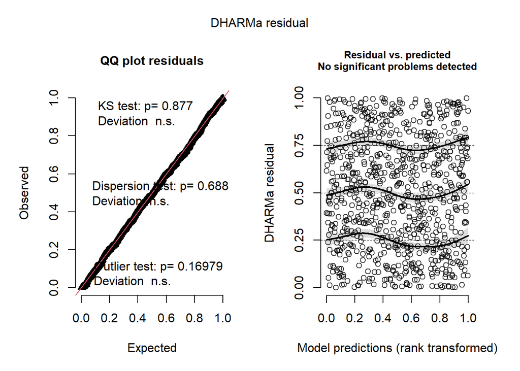

```r
resid.loss1=simulateResiduals(M.loss2_global.model, plot=TRUE)
```

```r
vif(M.loss2_global.model)
```

```
##                         GVIF Df GVIF^(1/(2*Df))
## migrant_cat         1.158187  1        1.076191
## sex_cat             1.045524  1        1.022509
## yrseducation_sd     1.120330  1        1.058457
## trustleaders_sd     1.035175  1        1.017436
## decispart_cat       1.119675  2        1.028663
## marlivprim_cat      1.252481  1        1.119143
## mslall_sd           1.624475  1        1.274549
## occdiv_sd           1.390088  1        1.179020
## CommEvent_sd        1.060731  1        1.029918
## popn_sd             1.717362  1        1.310482
## distmktreg_sd       1.288776  1        1.135243
## regr_cat            1.386187  1        1.177364
## regg_cat            2.247337  1        1.499112
## rega_cat            1.602246  1        1.265799
## clearboundaries_cat 1.339496  1        1.157366
## confmechinter_sd    1.194874  1        1.093103
## GradSanctions_cat   1.609459  1        1.268644
```

```r
#loss2.dredge<-dredge(global.model = M.loss2_global.model, trace = TRUE)#This line of code was
#run on the HPC of James Cook University. It will take a long time to run.
#Consider running this code in your own computer.
```

Load dredge output

```r
loss2.2_dredge_sd<-readRDS(file="loss2.2.dredge.sd.rds")
```

average model

```r
loss2.average_sd<-summary(model.avg(loss2.2_dredge_sd, subset = delta <= 2))
```

```r
loss2.average_sd
```

```
##
## Call:
## model.avg(object = loss2.2_dredge_sd, subset = delta <= 2)
##
## Component model call:
## glmer(formula = Ineq2_bin ~ <14 unique rhs>, data = INEQ_loss2, family
##      = binomial(link = "logit"), control = glmerControl(optimizer =
##      "bobyqa", optCtrl = list(maxfun = 1e+06)), na.action = na.fail)
##
## Component models:
##                        df  logLik   AICc delta weight
## 1+4+5+8+9+10+11+12     10 -453.34 926.95  0.00   0.12
## 1+2+4+5+8+9+10+11+12   11 -452.53 927.38  0.43   0.10
## 1+4+5+8+9+10+11         9 -454.61 927.44  0.49   0.10
## 1+3+4+5+8+9+10+11+12   11 -452.69 927.70  0.75   0.09
## 1+4+5+6+8+9+10+11+12   11 -452.81 927.94  1.00   0.08
## 1+2+4+5+8+9+10+11      10 -453.87 928.01  1.06   0.07
## 1+3+4+5+8+9+10+11      10 -453.93 928.13  1.18   0.07
## 1+2+4+5+6+8+9+10+11+12 12 -451.90 928.17  1.23   0.07
## 1+2+3+4+5+8+9+10+11+12 12 -452.13 928.64  1.69   0.05
## 1+3+4+5+6+8+9+10+11+12 12 -452.13 928.65  1.70   0.05
## 1+4+5+7+8+9+10+11+12   11 -453.21 928.75  1.80   0.05
## 1+4+5+8+9+10+11+12+13  11 -453.21 928.75  1.80   0.05
## 1+4+5+6+8+9+10+11      10 -454.28 928.84  1.89   0.05
## 1+4+5+8+9+10+11+12+14  11 -453.28 928.87  1.93   0.05
##
## Term codes:
##        CommEvent_sd   GradSanctions_cat clearboundaries_cat    confmechinter_sd
##                   1                   2                   3                   4
##       distmktreg_sd      marlivprim_cat         migrant_cat           mslall_sd
##                   5                   6                   7                   8
##             popn_sd            rega_cat            regg_cat             sex_cat
##                   9                  10                  11                  12
##     trustleaders_sd     yrseducation_sd
##                  13                  14
##
## Model-averaged coefficients:
## (full average)
##                       Estimate Std. Error Adjusted SE z value Pr(>|z|)
## (Intercept)          -0.661523   0.554615    0.555169   1.192  0.23343
```

[output cut: 19 more lines]

```
## confmechinter_sd     -0.62499    0.24571     0.24607   2.540  0.01109 *
## distmktreg_sd         0.50985    0.21757     0.21788   2.340  0.01928 *
## mslall_sd            -0.61968    0.24368     0.24404   2.539  0.01111 *
## popn_sd               0.94420    0.29349     0.29391   3.213  0.00132 **
## rega_cat1             0.88404    0.27057     0.27094   3.263  0.00110 **
## regg_cat1            -1.49062    0.34185     0.34231   4.355 1.33e-05 ***
## sex_catM              0.67928    0.43349     0.43413   1.565  0.11765
## GradSanctions_cat1    0.35470    0.28749     0.28791   1.232  0.21795
## clearboundaries_cat1 -0.28604    0.25733     0.25771   1.110  0.26703
## marlivprim_cat1      -0.24230    0.23842     0.23877   1.015  0.31020
## migrant_cat1          0.16940    0.33329     0.33378   0.508  0.61180
## trustleaders_sd       0.08793    0.17537     0.17563   0.501  0.61663
## yrseducation_sd       0.06508    0.18211     0.18238   0.357  0.72122
## ---
## Signif. codes:  0 '***' 0.001 '**' 0.01 '*' 0.05 '.' 0.1 ' ' 1
```

Relative influence

```r
sw(loss2.average_sd)
```

```
##                      CommEvent_sd confmechinter_sd distmktreg_sd mslall_sd
## Sum of weights:      1.00         1.00             1.00          1.00
## N containing models:   14           14               14            14
##                      popn_sd rega_cat regg_cat sex_cat GradSanctions_cat
## Sum of weights:      1.00    1.00     1.00     0.71    0.30
## N containing models:   14      14       14       10       4
##                      clearboundaries_cat marlivprim_cat migrant_cat
## Sum of weights:      0.26                0.25           0.05
## N containing models:    4                   4              1
##                      trustleaders_sd yrseducation_sd
## Sum of weights:      0.05            0.05
## N containing models:    1               1
```

```r
confint(loss2.average_sd,full=T,level=0.9) #full model averages
```

```
##                              5 %        95 %
## (Intercept)          -1.57448009  0.25143386
## CommEvent_sd          0.20163765  0.79593818
## confmechinter_sd     -1.02959655 -0.22038706
## distmktreg_sd         0.15158348  0.86811416
## mslall_sd            -1.02095624 -0.21841159
## popn_sd               0.46092312  1.42748302
## rega_cat1             0.43852704  1.32955931
## regg_cat1            -2.05348559 -0.92775496
## sex_catM             -0.30368241  1.26960691
## GradSanctions_cat1   -0.26543758  0.47505257
## clearboundaries_cat1 -0.37469787  0.22480671
## marlivprim_cat1      -0.31874708  0.19983982
## migrant_cat1         -0.12939782  0.14660806
## trustleaders_sd      -0.06788479  0.07679734
## yrseducation_sd      -0.06621240  0.07241312
```

```r
ma.loss2<-summary(loss2.average_sd)#pulling out model averages
```

```r
df.loss2<-as.data.frame(ma.loss2$coefmat.full)#selecting full model coefficient averages
```

```r
CI<-as.data.frame(confint(loss2.average_sd,level=0.9,full=T))# to get confident intervals
#for full model
```

```r
CI
```

```
##                              5 %        95 %
## (Intercept)          -1.57448009  0.25143386
## CommEvent_sd          0.20163765  0.79593818
## confmechinter_sd     -1.02959655 -0.22038706
## distmktreg_sd         0.15158348  0.86811416
## mslall_sd            -1.02095624 -0.21841159
## popn_sd               0.46092312  1.42748302
## rega_cat1             0.43852704  1.32955931
## regg_cat1            -2.05348559 -0.92775496
## sex_catM             -0.30368241  1.26960691
## GradSanctions_cat1   -0.26543758  0.47505257
## clearboundaries_cat1 -0.37469787  0.22480671
## marlivprim_cat1      -0.31874708  0.19983982
## migrant_cat1         -0.12939782  0.14660806
## trustleaders_sd      -0.06788479  0.07679734
## yrseducation_sd      -0.06621240  0.07241312
```

```r
df.loss2$CI.min <-CI$`5 %` #pulling out CIs and putting into same df as coefficient estimates
```

```r
df.loss2$CI.max <-CI$`95 %`
```

```r
df.loss2
```

```
##                          Estimate Std. Error Adjusted SE    z value  Pr(>|z|)
## (Intercept)          -0.661523117 0.55461452  0.55516858 1.19157160 0.2334293
## CommEvent_sd          0.498787918 0.18045003  0.18071731 2.76004507 0.0057793
## confmechinter_sd     -0.624991806 0.24570706  0.24606668 2.53992863 0.0110875
## distmktreg_sd         0.509848822 0.21756796  0.21788412 2.33999997 0.0192837
## mslall_sd            -0.619683913 0.24368421  0.24403976 2.53927441 0.0111083
## popn_sd               0.944203070 0.29348551  0.29391398 3.21251498 0.0013158
## rega_cat1             0.884043177 0.27056707  0.27094283 3.26284024 0.0011030
## regg_cat1            -1.490620274 0.34184831  0.34230511 4.35465392 0.0000133
## sex_catM              0.482962249 0.47792993  0.47834304 1.00965669 0.3126598
## GradSanctions_cat1    0.104807498 0.22497089  0.22513053 0.46554103 0.6415441
## clearboundaries_cat1 -0.074945578 0.18212939  0.18226933 0.41118041 0.6809402
## marlivprim_cat1      -0.059453631 0.15753996  0.15766971 0.37707707 0.7061163
## migrant_cat1          0.008605120 0.08382340  0.08392329 0.10253554 0.9183316
## trustleaders_sd       0.004456277 0.04393997  0.04399261 0.10129603 0.9193155
## yrseducation_sd       0.003100364 0.04209656  0.04215225 0.07355158 0.9413672
##                           CI.min      CI.max
## (Intercept)          -1.57448009  0.25143386
## CommEvent_sd          0.20163765  0.79593818
## confmechinter_sd     -1.02959655 -0.22038706
## distmktreg_sd         0.15158348  0.86811416
## mslall_sd            -1.02095624 -0.21841159
## popn_sd               0.46092312  1.42748302
## rega_cat1             0.43852704  1.32955931
## regg_cat1            -2.05348559 -0.92775496
## sex_catM             -0.30368241  1.26960691
## GradSanctions_cat1   -0.26543758  0.47505257
## clearboundaries_cat1 -0.37469787  0.22480671
## marlivprim_cat1      -0.31874708  0.19983982
## migrant_cat1         -0.12939782  0.14660806
## trustleaders_sd      -0.06788479  0.07679734
## yrseducation_sd      -0.06621240  0.07241312
```

```r
setDT(df.loss2, keep.rownames='coefficient')#put row names into columns
```

```r
names(df.loss2) <- gsub(" ",'',names(df.loss2))#remove spaces from column headers
```

Plot standardized effects

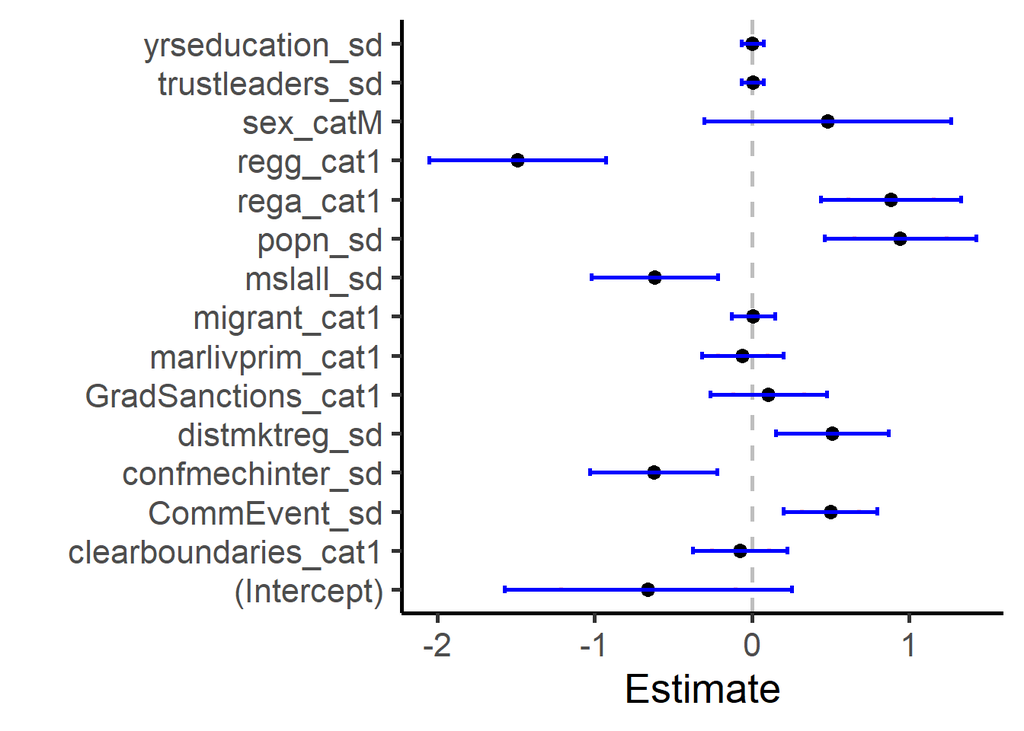

```r
ggplot(data=df.loss2, aes(x=coefficient, y=Estimate))+
  geom_hline(yintercept=0, color='grey', linetype='dashed', lwd=1)+
  geom_errorbar(aes(ymin=Estimate-Std.Error, ymax=Estimate+Std.Error), colour="pink",#SE
         width=.1, lwd=1)+
    coord_flip()+
    geom_point(size=3)+theme_classic(base_size=20)+xlab("")+
  geom_errorbar(aes(ymin=CI.min, ymax=CI.max), colour="blue", # CIs
                width=.2,lwd=1)
```

### MODEL SUBJECTIVE GAINS (Disparity 2)

Define global model

```r
M.gains2_global.model<-glmer(Ineq2_bin ~ migrant_cat+ sex_cat + yrseducation_sd +
trustleaders_sd +decispart_cat + marlivprim_cat + mslall_sd + occdiv_sd + CommEvent_sd+
       popn_sd + distmktreg_sd  +  regr_cat + regg_cat + rega_cat + clearboundaries_cat  +
        confmechinter_sd + GradSanctions_cat +(1 | site_cat),
          data = INEQ_gain2,family=binomial(link = "logit"), na.action='na.fail',
            control = glmerControl(optimizer="bobyqa",optCtrl=list(maxfun=1000000)))
```

```r
summary(M.gains2_global.model)
```

```
## Generalized linear mixed model fit by maximum likelihood (Laplace
##   Approximation) [glmerMod]
##  Family: binomial  ( logit )
## Formula:
## Ineq2_bin ~ migrant_cat + sex_cat + yrseducation_sd + trustleaders_sd +
##     decispart_cat + marlivprim_cat + mslall_sd + occdiv_sd +
##     CommEvent_sd + popn_sd + distmktreg_sd + regr_cat + regg_cat +
##     rega_cat + clearboundaries_cat + confmechinter_sd + GradSanctions_cat +
##     (1 | site_cat)
##    Data: INEQ_gain2
## Control: glmerControl(optimizer = "bobyqa", optCtrl = list(maxfun = 1e+06))
##
##      AIC      BIC   logLik deviance df.resid
##    532.6    622.5   -246.3    492.6      643
##
## Scaled residuals:
##     Min      1Q  Median      3Q     Max
## -1.1603 -0.4236 -0.3269 -0.2363  5.8552
##
## Random effects:
##  Groups   Name        Variance Std.Dev.
##  site_cat (Intercept) 0.06087  0.2467
## Number of obs: 663, groups:  site_cat, 47
##
## Fixed effects:
##                      Estimate Std. Error z value Pr(>|z|)
## (Intercept)          -2.18671    0.72052  -3.035  0.00241 **
## migrant_cat1          0.66240    0.47048   1.408  0.15916
## sex_catM             -0.05559    0.51946  -0.107  0.91477
## yrseducation_sd      -0.13734    0.25759  -0.533  0.59391
## trustleaders_sd       0.21903    0.24057   0.910  0.36257
## decispart_cat1        0.23820    0.34786   0.685  0.49349
## decispart_cat2       -0.02732    0.32885  -0.083  0.93379
## marlivprim_cat1      -0.07022    0.33548  -0.209  0.83420
## mslall_sd            -0.72498    0.34490  -2.102  0.03555 *
## occdiv_sd            -0.21754    0.29548  -0.736  0.46158
## CommEvent_sd          0.46586    0.22740   2.049  0.04049 *
## popn_sd               1.01549    0.36282   2.799  0.00513 **
## distmktreg_sd         0.31157    0.33472   0.931  0.35194
## regr_cat1             0.60831    0.39372   1.545  0.12234
## regg_cat1            -0.61179    0.47388  -1.291  0.19670
## rega_cat1            -0.15926    0.35153  -0.453  0.65051
## clearboundaries_cat1  0.65958    0.32879   2.006  0.04485 *
## confmechinter_sd     -0.35536    0.30427  -1.168  0.24284
## GradSanctions_cat1    0.44555    0.36317   1.227  0.21988
## ---
## Signif. codes:  0 '***' 0.001 '**' 0.01 '*' 0.05 '.' 0.1 ' ' 1
```

```
##
## Correlation matrix not shown by default, as p = 19 > 12.
## Use print(x, correlation=TRUE)  or
##     vcov(x)        if you need it
```

```r
check_overdispersion(M.gains2_global.model)
```

```
## # Overdispersion test
##
##        dispersion ratio =   1.044
##   Pearson's Chi-Squared = 671.279
##                 p-value =   0.213
```

```
## No overdispersion detected.
```

```r
check_singularity(M.gains2_global.model)
```

```
## [1] FALSE
```

```r
check_convergence(M.gains2_global.model)
```

```
## [1] TRUE
## attr(,"gradient")
## [1] 1.142812e-06
```

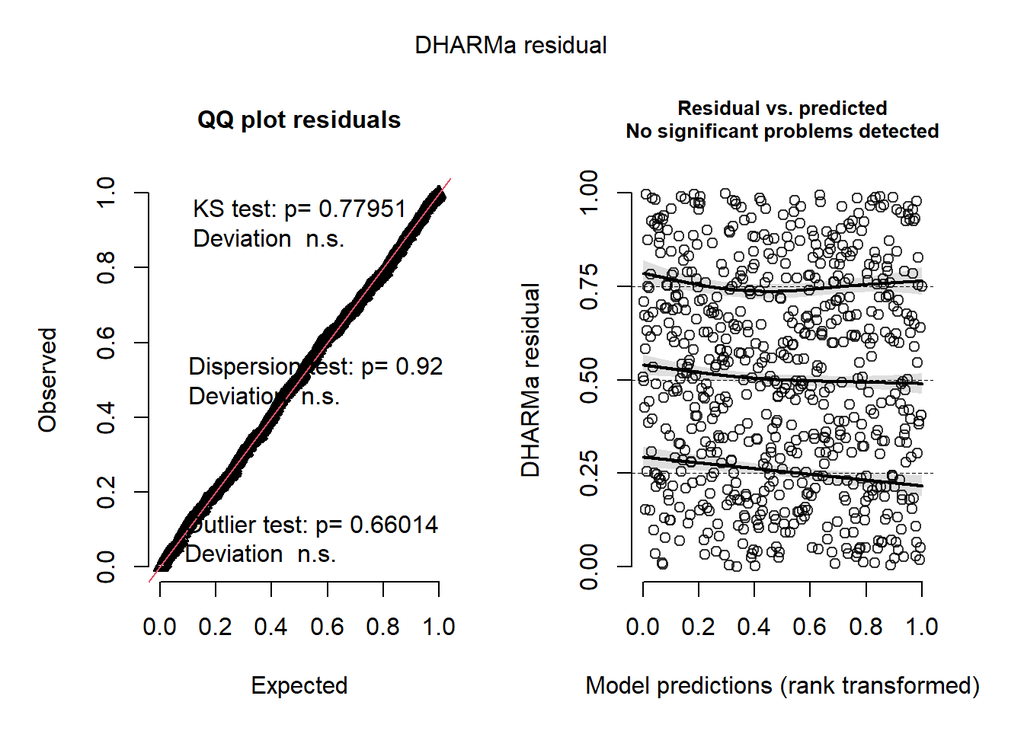

```r
resid.loss1=simulateResiduals(M.gains2_global.model, plot=TRUE)
```

```r
vif(M.gains2_global.model)
```

```
##                         GVIF Df GVIF^(1/(2*Df))
## migrant_cat         1.267181  1        1.125691
## sex_cat             1.081513  1        1.039958
## yrseducation_sd     1.172083  1        1.082628
## trustleaders_sd     1.083550  1        1.040937
## decispart_cat       1.124764  2        1.029830
## marlivprim_cat      1.223472  1        1.106107
## mslall_sd           1.851116  1        1.360557
## occdiv_sd           1.419366  1        1.191371
## CommEvent_sd        1.065046  1        1.032011
## popn_sd             2.132162  1        1.460192
## distmktreg_sd       1.374562  1        1.172417
## regr_cat            1.402307  1        1.184190
## regg_cat            2.334233  1        1.527820
## rega_cat            1.769661  1        1.330286
## clearboundaries_cat 1.517737  1        1.231965
## confmechinter_sd    1.441461  1        1.200608
## GradSanctions_cat   1.772031  1        1.331177
```

```r
#gains2.dredge<-dredge(global.model = M.gains2_global.model, trace = TRUE) #This line of
#code was run on the HPC of James Cook University. It will take a long time to run.
#Consider running this code in your own computer.
```

Load dredge output

```r
gains2.2_dredge_sd<-readRDS(file="gains2.2.dredge.sd.rds")
```

Model average

```r
gains2.average_sd<-summary(model.avg(gains2.2_dredge_sd, subset = delta <= 2))
```

```r
gains2.average_sd
```

```
##
## Call:
## model.avg(object = gains2.2_dredge_sd, subset = delta <= 2)
##
## Component model call:
## glmer(formula = Ineq2_bin ~ <46 unique rhs>, data = INEQ_gain2, family
##      = binomial(link = "logit"), control = glmerControl(optimizer =
##      "bobyqa", optCtrl = list(maxfun = 1e+06)), na.action = na.fail)
##
## Component models:
##                  df  logLik   AICc delta weight
## 1+3+7+8+10        7 -250.82 515.81  0.00   0.04
## 1+3+8+10          6 -252.00 516.12  0.31   0.04
## 1+7+8+10          6 -252.05 516.23  0.41   0.03
## 1+3+4+8+10        7 -251.04 516.25  0.44   0.03
## 1+4+8+10          6 -252.19 516.51  0.70   0.03
## 1+3+7+8+9+10      8 -250.16 516.54  0.73   0.03
## 1+3+8+9+10        7 -251.19 516.54  0.73   0.03
## 1+3+4+8+9+10      8 -250.20 516.63  0.81   0.03
## 1+8+10            5 -253.34 516.77  0.95   0.03
## 1+3+4+7+8+10      8 -250.29 516.80  0.99   0.03
## 1+4+7+8+10        7 -251.34 516.86  1.04   0.02
## 1+3+8+10+12       7 -251.36 516.90  1.08   0.02
## 1+3+7+8+10+12     8 -250.34 516.90  1.09   0.02
## 1+7+8+10+11       7 -251.44 517.05  1.24   0.02
## 1+3+7+8+10+13     8 -250.43 517.09  1.28   0.02
## 1+7+8+10+12       7 -251.46 517.10  1.29   0.02
## 1+3+7+8+10+14     8 -250.45 517.12  1.30   0.02
## 1+4+8+10+12       7 -251.51 517.18  1.37   0.02
## 1+4+7+8+10+11     8 -250.48 517.19  1.37   0.02
## 1+3+4+8+10+12     8 -250.48 517.19  1.38   0.02
## 1+8+10+12         6 -252.56 517.24  1.43   0.02
## 1+4+8+10+11       7 -251.54 517.25  1.43   0.02
## 1+3+8+10+14       7 -251.56 517.30  1.49   0.02
## 1+4+8+9+10        7 -251.58 517.32  1.51   0.02
## 1+7+8+9+10        7 -251.58 517.34  1.53   0.02
## 1+3+4+8+10+14     8 -250.56 517.34  1.53   0.02
## 1+3+7+8+9+10+13   9 -249.55 517.38  1.57   0.02
## 1+3+5+7+8+10      8 -250.58 517.38  1.57   0.02
## 1+3+8+9+10+13     8 -250.59 517.40  1.58   0.02
```

[output cut: 53 more lines]

```
## migrant_cat1          0.68703    0.45056     0.45137   1.522  0.12799
## mslall_sd            -0.83517    0.33517     0.33574   2.488  0.01286 *
## popn_sd               0.95718    0.34652     0.34711   2.758  0.00582 **
## confmechinter_sd     -0.40586    0.29220     0.29272   1.387  0.16559
## occdiv_sd            -0.34396    0.28509     0.28561   1.204  0.22847
## regg_cat1            -0.45547    0.38963     0.39034   1.167  0.24327
## rega_cat1            -0.33812    0.33323     0.33381   1.013  0.31111
## regr_cat1             0.40321    0.39247     0.39317   1.026  0.30512
## trustleaders_sd       0.22105    0.24624     0.24670   0.896  0.37023
## distmktreg_sd         0.19123    0.27255     0.27305   0.700  0.48372
## GradSanctions_cat1    0.29819    0.36202     0.36264   0.822  0.41092
## marlivprim_cat1       0.15118    0.31371     0.31429   0.481  0.63050
## yrseducation_sd      -0.09208    0.25171     0.25217   0.365  0.71499
## ---
## Signif. codes:  0 '***' 0.001 '**' 0.01 '*' 0.05 '.' 0.1 ' ' 1
```

Relative influence

```r
sw(gains2.average_sd)
```

```
##                      mslall_sd popn_sd CommEvent_sd clearboundaries_cat
## Sum of weights:      1.00      1.00    0.98         0.65
## N containing models:   46        46      45           30
##                      migrant_cat confmechinter_sd occdiv_sd regg_cat regr_cat
## Sum of weights:      0.50        0.36             0.21      0.20     0.15
## N containing models:   23          17               10        10        8
##                      trustleaders_sd rega_cat distmktreg_sd GradSanctions_cat
## Sum of weights:      0.09            0.08     0.04          0.03
## N containing models:    5               4        2             2
##                      marlivprim_cat yrseducation_sd
## Sum of weights:      0.02           0.02
## N containing models:    1              1
```

```r
confint(gains2.average_sd,full=T,level=0.9) #full model averages
```

```
##                              5 %        95 %
## (Intercept)          -2.73063233 -1.58536934
## CommEvent_sd          0.06227531  0.78752979
## clearboundaries_cat1 -0.24292573  0.92034783
## migrant_cat1         -0.42775981  1.11418513
## mslall_sd            -1.38718952 -0.28315668
## popn_sd               0.38646257  1.52790150
## confmechinter_sd     -0.57929826  0.28526260
## occdiv_sd            -0.39179523  0.24434365
## regg_cat1            -0.50544067  0.32365418
## rega_cat1            -0.24675896  0.19131638
## regr_cat1            -0.28120104  0.39857035
## trustleaders_sd      -0.14329495  0.18528942
## distmktreg_sd        -0.09550829  0.10896879
## GradSanctions_cat1   -0.13139609  0.15172540
## marlivprim_cat1      -0.07178261  0.07687870
## yrseducation_sd      -0.05728759  0.05433759
```

```r
ma.gains2<-summary(gains2.average_sd)#pulling out model averages
```

```r
df.gains2<-as.data.frame(ma.gains2$coefmat.full)#selecting full model coefficient averages
```

```r
CI<-as.data.frame(confint(gains2.average_sd,level=0.9,full=T))# to get confident intervals
#for full model
```

```r
CI
```

```
##                              5 %        95 %
## (Intercept)          -2.73063233 -1.58536934
## CommEvent_sd          0.06227531  0.78752979
## clearboundaries_cat1 -0.24292573  0.92034783
## migrant_cat1         -0.42775981  1.11418513
## mslall_sd            -1.38718952 -0.28315668
## popn_sd               0.38646257  1.52790150
## confmechinter_sd     -0.57929826  0.28526260
## occdiv_sd            -0.39179523  0.24434365
## regg_cat1            -0.50544067  0.32365418
## rega_cat1            -0.24675896  0.19131638
## regr_cat1            -0.28120104  0.39857035
## trustleaders_sd      -0.14329495  0.18528942
## distmktreg_sd        -0.09550829  0.10896879
## GradSanctions_cat1   -0.13139609  0.15172540
## marlivprim_cat1      -0.07178261  0.07687870
## yrseducation_sd      -0.05728759  0.05433759
```

```r
df.gains2$CI.min <-CI$`5 %` #pulling out CIs and putting into same df as coefficient estimates
```

```r
df.gains2$CI.max <-CI$`95 %`
```

```r
df.gains2
```

```
##                          Estimate Std. Error Adjusted SE    z value  Pr(>|z|)
## (Intercept)          -2.158000837 0.34784541  0.34822425 6.19715834 0.0000000
## CommEvent_sd          0.424902553 0.22017197  0.22055068 1.92655291 0.0540354
## clearboundaries_cat1  0.338711049 0.35335927  0.35368709 0.95765737 0.3382356
## migrant_cat1          0.343212662 0.46841819  0.46881008 0.73209318 0.4641117
## mslall_sd            -0.835173101 0.33516626  0.33573601 2.48758868 0.0128612
## popn_sd               0.957182036 0.34651799  0.34711246 2.75755598 0.0058235
## confmechinter_sd     -0.147017830 0.26264675  0.26285733 0.55930657 0.5759525
## occdiv_sd            -0.073725790 0.19324724  0.19341097 0.38118722 0.7030643
## regg_cat1            -0.090893245 0.25186036  0.25207811 0.36057572 0.7184166
## rega_cat1            -0.027721290 0.13307363  0.13319365 0.20812771 0.8351292
## regr_cat1             0.058684654 0.20648642  0.20668173 0.28393731 0.7764584
## trustleaders_sd       0.020997239 0.09980107  0.09990759 0.21016661 0.8335376
## distmktreg_sd         0.006730251 0.06209703  0.06217492 0.10824704 0.9137997
## GradSanctions_cat1    0.010164659 0.08599478  0.08608372 0.11807875 0.9060053
## marlivprim_cat1       0.002548045 0.04513777  0.04520581 0.05636543 0.9550507
## yrseducation_sd      -0.001474999 0.03388923  0.03394467 0.04345303 0.9653404
##                           CI.min      CI.max
## (Intercept)          -2.73063233 -1.58536934
## CommEvent_sd          0.06227531  0.78752979
## clearboundaries_cat1 -0.24292573  0.92034783
## migrant_cat1         -0.42775981  1.11418513
## mslall_sd            -1.38718952 -0.28315668
## popn_sd               0.38646257  1.52790150
## confmechinter_sd     -0.57929826  0.28526260
## occdiv_sd            -0.39179523  0.24434365
## regg_cat1            -0.50544067  0.32365418
## rega_cat1            -0.24675896  0.19131638
## regr_cat1            -0.28120104  0.39857035
## trustleaders_sd      -0.14329495  0.18528942
## distmktreg_sd        -0.09550829  0.10896879
## GradSanctions_cat1   -0.13139609  0.15172540
## marlivprim_cat1      -0.07178261  0.07687870
## yrseducation_sd      -0.05728759  0.05433759
```

```r
setDT(df.gains2, keep.rownames='coefficient')#put row names into columns
```

```r
names(df.gains2) <- gsub(" ",'',names(df.gains2))#remove spaces from column headers
```

Plot standardized effects

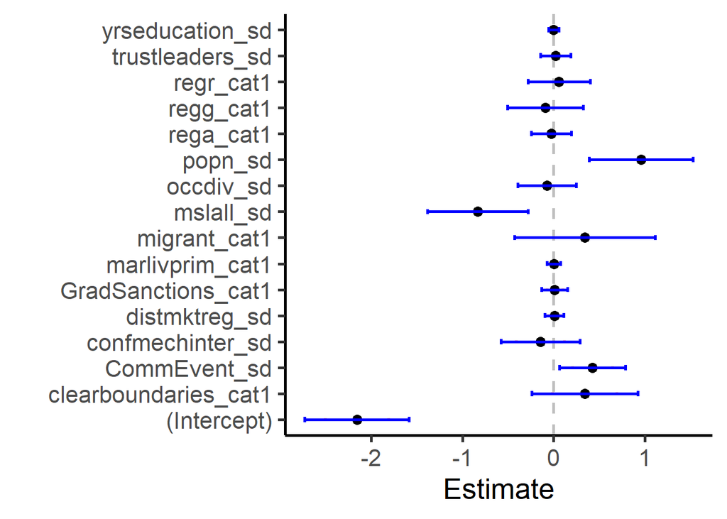

```r
ggplot(data=df.gains2, aes(x=coefficient, y=Estimate))+
  geom_hline(yintercept=0, color='grey', linetype='dashed', lwd=1)+
  geom_errorbar(aes(ymin=Estimate-Std.Error, ymax=Estimate+Std.Error), colour="pink",#SE
         width=.1, lwd=1)+
    coord_flip()+
    geom_point(size=3)+theme_classic(base_size=20)+xlab("")+
  geom_errorbar(aes(ymin=CI.min, ymax=CI.max), colour="blue", # CIs
                width=.2,lwd=1)
```